# TP FINAL

2023-06-21

## Introducción

Los datos a analizar provienen de la Encuesta sobre Uso del tiempo, realizada en el 2016 por el Gobierno de la Ciudad de Buenas Aires (GCBA). Según la Dirección de estadísticas del GCBA, la encuesta tiene por objetivo producir información sobre el tiempo que las personas (mujeres y varones, jóvenes, personas mayores) que habitan en la Ciudad de Buenos Aires dedican cotidianamente a diferentes actividades, incluyendo el trabajo remunerado, las actividades domésticas, el cuidado de niños, niñas, personas mayores o con discapacidad, el estudio, el esparcimiento, los viajes y traslados, etc.

El diseño muestral de la Encuesta es estratificado en tres etapas: En la primera etapa de muestreo se seleccionaron 300 (unidades primarias de muestreo) UPM con probabilidad de selección proporcional al tamaño, en este caso de las viviendas. En la segunda etapa, se seleccionaron de manera sistemática 15 viviendas en cada una de las UPM, totalizando una muestra de 4.500 viviendas. La última etapa consistió en la selección de un miembro del hogar de 14 o más años. Se contempla la existencia de 6 factores de expansión que No están en la base de microdatos disponible.

## Exploración de la base de datos

Leo los datos y el encabezado de las variables

```r
uso_tiempo <- read.csv("datos/encuesta_uso_tiempo_2016.csv")
```

Se trata de una base organizada en 27 columnas de variables con 2.336 observaciones.Un grupo de variables socioeconomicas (edad, sexo ,estado ocupacional ,quintil de ingreso, etc) y otro grupo sobre actividades remuneradas, no remuneradas, recreativas y de estudio.

```r
head(uso_tiempo)
```

```
##   hogar  sexo edad       dia_laborable trabajo_pago trabajo_domestico_no_pago
## 1   1_1 Varon   14 D\xeda no laborable            0                       0.1
## 2   2_1 Varon   14 D\xeda no laborable            0                       1.0
## 3   3_1 Varon   14 D\xeda no laborable            0                       0.2
## 4   4_1 Varon   14 D\xeda no laborable            0                       1.8
## 5   5_1 Varon   14 D\xeda no laborable            0                       0.0
## 6   6_1 Mujer   14 D\xeda no laborable            0                       3.0
##   voluntariados estudio_educacion recreacion aplicaciones tareas_cuidados
## 1             0               0.0        9.0          7.3               0
## 2             0               8.3        2.7          2.5               0
## 3             0              11.3        2.6          0.3               0
## 4             0               4.0        7.7          3.0               0
## 5             0               8.3        4.7          1.8               0
## 6             0               0.0        4.2          4.8               0
##   cuidado_personal trabajo_pago2 trabajo_domestico_no_pago2 voluntariados2
```

[output cut: 34 more lines]

**Se calculan algunos estadísticos para conocer la base**.

Calculo la frecuencia del grupo de edades de la muestra.

```r
uso_tiempo |>

freq( rango_etario)|>

  knitr::kable (caption = "Participación según grupo etario:", col.names = c( "N", "Participación %( válidos)", "Partipación acumulada (válidos)", "Participación % (Total)", "Partipación acumulada (Total)"))
```

Participación según grupo etario:

|  | N | Participación %( válidos) | Partipación acumulada (válidos) | Participación % (Total) | Partipación acumulada (Total) |
| --- | --- | --- | --- | --- | --- |
| 14-24 | 291 | 12.45719 | 12.45719 | 12.45719 | 12.45719 |
| 25-39 | 672 | 28.76712 | 41.22432 | 28.76712 | 41.22432 |
| 40-49 | 307 | 13.14212 | 54.36644 | 13.14212 | 54.36644 |
| 50-64 | 521 | 22.30308 | 76.66952 | 22.30308 | 76.66952 |
| 65+ | 545 | 23.33048 | 100.00000 | 23.33048 | 100.00000 |
|  | 0 | NA | NA | 0.00000 | 100.00000 |
| Total | 2336 | 100.00000 | 100.00000 | 100.00000 | 100.00000 |

Gráfico la frecuencia de las edades.

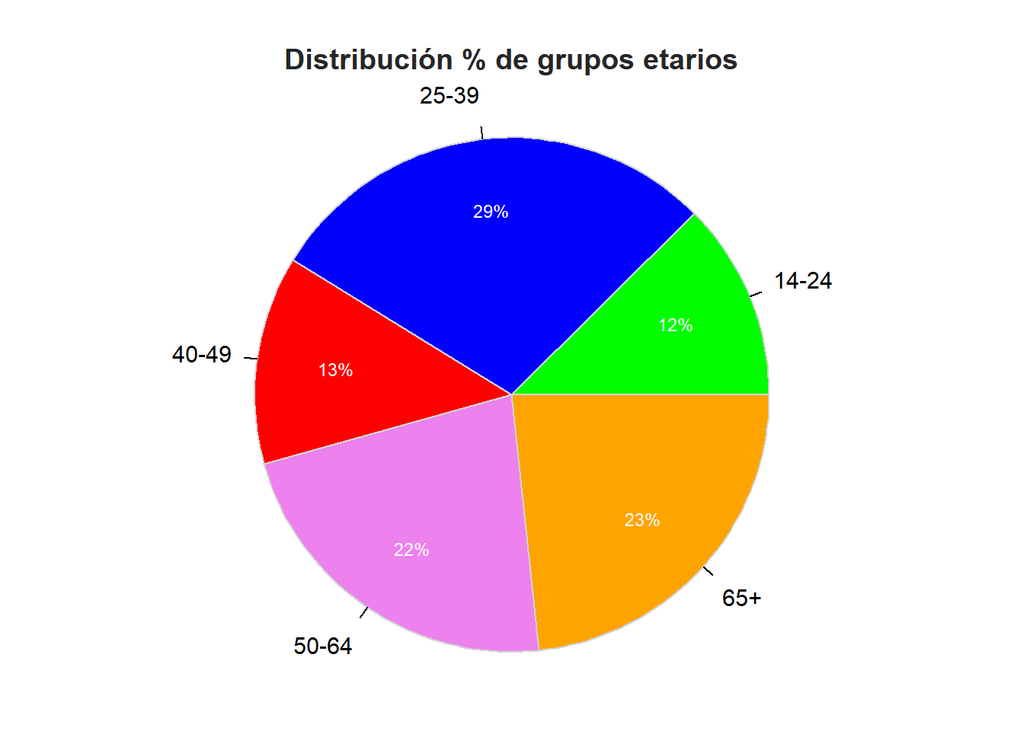

```
## >>> suggestions
## PieChart(rango_etario, hole=0)  # traditional pie chart
## PieChart(rango_etario, values="%")  # display %'s on the chart
## PieChart(rango_etario)  # bar chart
## Plot(rango_etario)  # bubble plot
## Plot(rango_etario, values="count")  # lollipop plot
##
## --- rango_etario ---
##
##                14-24  25-39  40-49  50-64    65+      Total
## Frequencies:     291    672    307    521    545       2336
## Proportions:   0.125  0.288  0.131  0.223  0.233      1.000
##
## Chi-squared test of null hypothesis of equal probabilities
##   Chisq = 230.310, df = 4, p-value = 0.000
```

```r
PieChart(rango_etario, data = uso_tiempo, hole = 0, values = "%", ,
         fill = c("green", "blue", "red", "violet","orange"), main = "Distribución % de grupos etarios")
```

**Calculo el rango para las principales variables**.

Rango para trabajo pago.

```r
rango_trabajo_pago <- range (uso_tiempo$trabajo_pago2, na.rm = TRUE)
```

La variable trabajo pago, que indica la cantidad de horas diarias dedicadas a tareas remuneradas (de mercado). Toma valores en 0 y 22.5, se encuentra expresado en horas y minutos.

Rango para trabajo doméstico no pago.

```r
Rango_domestico_no_pago <- range(uso_tiempo$trabajo_domestico_no_pago2)
```

La variable tareas domésticas no pagas, que indica la cantidad de horas diarias dedicadas a tareas en el hogar no remuneradas, toma valores entre 0 y 12.8 horas.

```r
rango_voluntariado <- range(uso_tiempo$voluntariados2)
```

La variable voluntariado, que indica la cantidad de horas diarias dedicadas a servicios a la comunidad y ayudas no pagas, toma valores entre 0 y 13.5.

Rango para tareas de cuidados

```r
rango_cuidados <- range(uso_tiempo$tareas_cuidados2)
```

La variable cuidados, que indica la cantidad de horas diarias no remuneradas dedicadas a tareas de cuidados a miembros de hogar. Toma valores entre 0 y 13.2.

Rango para tareas uso de aplicaciones

```r
rango_aplicaciones <- range(uso_tiempo$aplicaciones2)
```

La variable aplicaciones, que denota la cantidad de horas diarias dedicadas al uso de aplicaciones tecnológicas y medios de comunicación, toma valores entre 0 y 14.3.

Rango para tareas tiempo de recreación

```r
rango_recreacion <- range(uso_tiempo$recreacion2)
```

La variable recreación, expresa la cantidad de horas diarias dedicadas al ocio, convivencia y actividades recreativa, toma valores entre 0 y 15.9.

Se observa el limite superior máximo se registra en lo referido a tareas remuneradas, el resto de las tareas presentan limites similares.

**Calcula la frecuencia para la variable quintil de ingreso**.

```r
uso_tiempo|>
  freq(quintil_ingreso)
```

```
## Frequencies
## uso_tiempo$quintil_ingreso
## Type: Character
##
##                     Freq   % Valid   % Valid Cum.   % Total   % Total Cum.
## ----------------- ------ --------- -------------- --------- --------------
##       5to quintil   2336    100.00         100.00    100.00         100.00
##              <NA>      0                               0.00         100.00
##             Total   2336    100.00         100.00    100.00         100.00
```

Se observaban anomalías en la variable quintil de ingreso, la frecuencia de dicha variable arrojo un solo quintil para toda la muestra.La cantidad de observaciones coincide con la muestra, por tal se asignó a todas las observaciones el mismo quintil de ingreso.

**Calculo la propoción de hombres y mujeres en la muestra**.

```r
  prop.table(table(uso_tiempo$sexo)) |>

   knitr::kable(caption = "Participación según sexo:", col.names = c("Sexo", "Participación"))
```

Participación según sexo:

| Sexo | Participación |
| --- | --- |
| Mujer | 0.5757705 |
| Varon | 0.4242295 |

Gráfico la proporción de hombres y mujeres en la muestra.

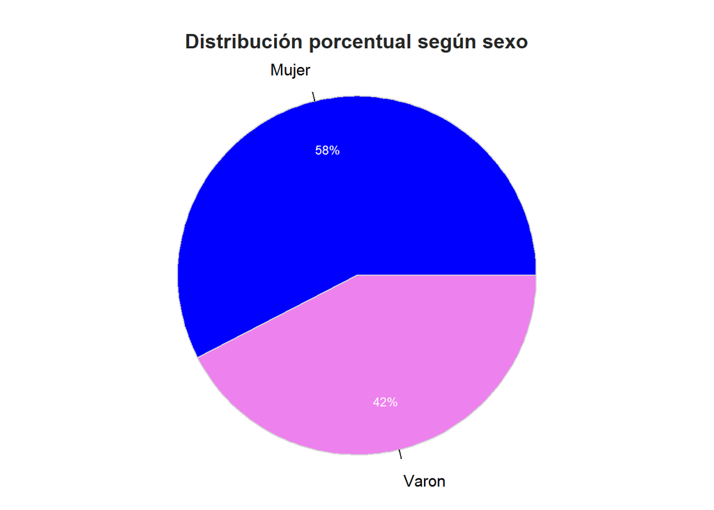

Elaboración propia en base a datos de la Encuesta sobre Uso del Tiempo, Dirección de Estadisticas y Censos, GCBS

```
## >>> suggestions
## PieChart(sexo, hole=0)  # traditional pie chart
## PieChart(sexo, values="%")  # display %'s on the chart
## PieChart(sexo)  # bar chart
## Plot(sexo)  # bubble plot
## Plot(sexo, values="count")  # lollipop plot
##
## --- sexo ---
##
##                Mujer  Varon      Total
## Frequencies:    1345    991       2336
## Proportions:   0.576  0.424      1.000
##
## Chi-squared test of null hypothesis of equal probabilities
##   Chisq = 53.646, df = 1, p-value = 0.000
```

```r
PieChart(sexo, data = uso_tiempo, hole = 0, values = "%",
         fill = c("blue", "violet"), main = "Distribución porcentual según sexo")
```

**Calculo la frecuencia del nivel educativo**.

```r
uso_tiempo|>

  freq(nivel_educativo)|>
  knitr::kable(caption = "Participación según nivel educativo:", col.names = c("N", "Participación %( válidos", "Partipación acumulada (válidos)", "Participación % (Total)", "Partipación acumulada (Total)"))
```

Participación según nivel educativo:

|  | N | Participación %( válidos | Partipación acumulada (válidos) | Participación % (Total) | Partipación acumulada (Total) |
| --- | --- | --- | --- | --- | --- |
| Escuela especial | 2 | 0.0856164 | 0.0856164 | 0.0856164 | 0.0856164 |
| Secundario completo/Superior incompleto | 977 | 41.8236301 | 41.9092466 | 41.8236301 | 41.9092466 |
| Secundario incompleto | 496 | 21.2328767 | 63.1421233 | 21.2328767 | 63.1421233 |
| Superior completo | 861 | 36.8578767 | 100.0000000 | 36.8578767 | 100.0000000 |
|  | 0 | NA | NA | 0.0000000 | 100.0000000 |
| Total | 2336 | 100.0000000 | 100.0000000 | 100.0000000 | 100.0000000 |

### Conclusión de la exploración de datos:

1. Se observa una menor participación en el grupo etarios de 14-24 y de 40- 49, en relación con los restantes grupos.
2. El 58% de las respuestas provienen del genero femenino.
3. No es posible utilizar la variable quintil de ingreso.
4. EL 37% de los encuestas posee estudios de nivel superior completo, 42% superior secundario completo y un 21% secundario incompleto.

## Hipótesis 1: Las mujeres dedican mayor cantidad de horas al trabajo no remunerado que los hombres.

Para ver ello se calcula, en primer lugar, la cantidad media de tiempo dedicada al trabajo pago en el día de referencia según sexo. Luego, se calcula lo mismo para aquella actividades no remuneradas. Para este segundo grupo se consideraron las siguientes variables: trabajo doméstico no remunerado, cuidados y voluntariado.De este modo, se obtienen valores promedio de trabajo remunerado y no remunerado por sexo.

```r
uso_tiempo|>
  group_by(sexo)|>
summarise(mean(trabajo_pago2,na.rm=TRUE),mean(trabajo_domestico_no_pago2, na.rm=TRUE),mean(tareas_cuidados2,na.rm=TRUE), mean(voluntariados2, na.rm=TRUE))|>
   knitr::kable(caption = "Promedio de horas remuneradas y no remuneradas según sexo:", col.names = c("Sexo", "Trabajo remunerado", "Trabajo doméstico no pago", "Tareas de cuidados", "Voluntariados"))
```

Promedio de horas remuneradas y no remuneradas según sexo:

| Sexo | Trabajo remunerado | Trabajo doméstico no pago | Tareas de cuidados | Voluntariados |
| --- | --- | --- | --- | --- |
| Mujer | 3.421190 | 2.737026 | 1.0379182 | 0.3731599 |
| Varon | 5.228355 | 1.626842 | 0.4860747 | 0.2515641 |

Se observa que las mujeres en general dedican en promedio mayor cantidad de horas a las actividades no remuneradas que los hombres. La mayor brecha se aprecia en el trabajo doméstico y la menor en voluntariados.

Para obtener una medida resumen se calcula una variable (hs_no_pago) que agrupa las actividades no remuneradas listadas previamente( sin incluir cuidado personal, recreacion y estudio).

```r
horas_no_pago <- uso_tiempo %>%

  mutate (hs_no_pago =(trabajo_domestico_no_pago2+voluntariados+tareas_cuidados2))
```

Luego, se calcula la cantidad media de horas dedicacadas a tareas no remuneradas según genero.

```r
horas_no_pago %>%
  group_by(sexo) %>%
  filter(hs_no_pago>0)|>
  summarise(promedio = mean(hs_no_pago)) %>%
  knitr::kable(caption = "Promedio de horas no remuneradas para cada sexo:", col.names = c("Sexo", "Promedio de horas"))
```

Promedio de horas no remuneradas para cada sexo:

| Sexo | Promedio de horas |
| --- | --- |
| Mujer | 4.524130 |
| Varon | 2.750057 |

Gráfico las horas medias de trabajo no pago por genero.

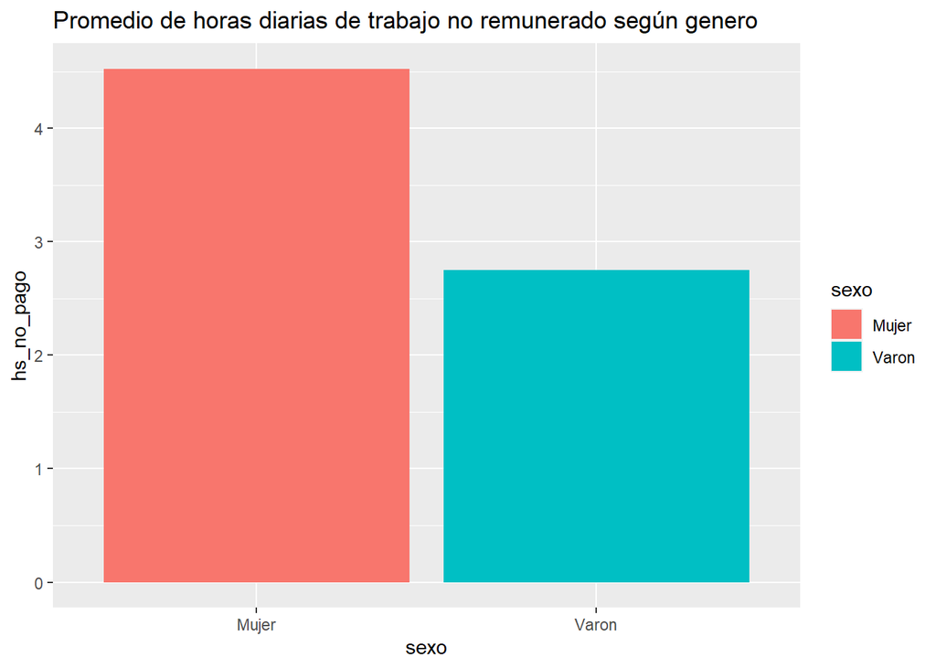

Elaboración propia en base a datos de la Encuesta sobre Uso del Tiempo, Dirección de Estadisticas y Censos, GCBS

```r
horas_no_pago|>
  group_by(sexo)|>
  filter(hs_no_pago>0)|>
  summarise(hs_no_pago = mean(hs_no_pago)) %>%
  ggplot(aes(sexo, hs_no_pago)) +
  geom_col(aes(fill = sexo))+
  labs(title = paste0("Promedio de horas diarias de trabajo no remunerado según genero "))
```

calculo el desvio estandar.

```r
horas_no_pago %>%
  group_by(sexo) %>%
  filter(hs_no_pago>0)|>
  summarise(desvio = sd(hs_no_pago)) %>%
  knitr::kable(caption = "Desvio de horas no remuneradas para cada sexo:", col.names = c("Sexo", "Promedio de horas"))
```

Desvio de horas no remuneradas para cada sexo:

| Sexo | Promedio de horas |
| --- | --- |
| Mujer | 3.535569 |
| Varon | 2.636083 |

### Conclusión hipótesis 1.

En promedio las mujeres realizan más horas de trabajo no remunerado que los hombres. Es decir, mientras que los hombres en el día de referencia realizaron poco menos de 3 horas de tareas no remuneradas,las mujeres hicieron cerca de 5 horas promedio.

Es importante destacar que el desvió es elevado, en el caso de las mujeres si bien en promedio realizan tareas no remuneradas por 4,5 horas en el día de referencia existe un desvió de más/menos 3,5 horas diarias. Para los hombres dicho desvió es de 3 horas.

## Hipótesis 2. La condición laboral se relaciona con la cantidad de horas que un individuo puede dedicar a tareas no remuneradas.

Calculo la proporción de la variable “condición laboral” para toda la muestra y según sexo.

```r
prop.table(table(uso_tiempo$estado_ocupacional)) |>


   knitr::kable(caption = "Participación según condición laboral:", col.names = c("Condición", "Participación"))
```

Participación según condición laboral:

| Condición | Participación |
| --- | --- |
| Desocupado | 0.0393836 |
| Inactivo | 0.2726884 |
| Ocupado | 0.6879281 |

```r
 uso_tiempo|>
  group_by(sexo)|>
  freq(estado_ocupacional)
```

```
## Frequencies
## estado_ocupacional
## Type: Character
## Group: sexo = Mujer
##
##                    Freq   % Valid   % Valid Cum.   % Total   % Total Cum.
## ---------------- ------ --------- -------------- --------- --------------
##       Desocupado     61      4.54           4.54      4.54           4.54
##         Inactivo    445     33.09          37.62     33.09          37.62
##          Ocupado    839     62.38         100.00     62.38         100.00
##             <NA>      0                               0.00         100.00
##            Total   1345    100.00         100.00    100.00         100.00
##
## Group: sexo = Varon
##
##                    Freq   % Valid   % Valid Cum.   % Total   % Total Cum.
## ---------------- ------ --------- -------------- --------- --------------
##       Desocupado     31      3.13           3.13      3.13           3.13
##         Inactivo    192     19.37          22.50     19.37          22.50
##          Ocupado    768     77.50         100.00     77.50         100.00
##             <NA>      0                               0.00         100.00
##            Total    991    100.00         100.00    100.00         100.00
```

El 69 % de la población encuestada está ocupada. Al cruzar estado ocupacional por sexo, se aprecia un porcentaje mayor de hombres ocupados, respecto de las mujeres. Mientras que son más las mujeres inactivas respecto de los hombres en terminos porcentuales, esto puede deberse a mayor esperanza de vida de las primeras.

Se observa como se distribuyen las horas de trabajo según la condicion laboral.

```r
uso_tiempo %>%
  group_by(estado_ocupacional) %>%
  filter(trabajo_pago2>0)|>
  summarise(horas_L_pago = mean(trabajo_pago2, na.rm = TRUE))|>

knitr::kable(caption = "Promedio de horas de trabajo remuneradas según estado ocupacional :", col.names = c("Estado ocupacional", "Promedio de horas"))
```

Promedio de horas de trabajo remuneradas según estado ocupacional :

| Estado ocupacional | Promedio de horas |
| --- | --- |
| Desocupado | 3.350000 |
| Inactivo | 2.590476 |
| Ocupado | 8.500000 |

```r
  horas_no_pago|>
      group_by(estado_ocupacional) %>%
  filter(hs_no_pago>0)|>
            summarise(hs_no_pago_media =(mean(hs_no_pago, na.rm=TRUE))) |>

  knitr::kable(caption = "Promedio de horas de trabajo no remunerado según estado ocupacional:", col.names = c("Estado ocupacional", "Promedio de horas"))
```

Promedio de horas de trabajo no remunerado según estado ocupacional:

| Estado ocupacional | Promedio de horas |
| --- | --- |
| Desocupado | 5.085393 |
| Inactivo | 4.466327 |
| Ocupado | 3.451436 |

La mayor cantidad promedio de trabajo remunerado se registra logicamente entre los ocupados. El trabajo doméstico y las tareas de cuidados son mayores entre los inactivos y los desocupados. En promedio una persona desocupada destina poco más de 5 horas a tareas no remuneradas, mientras que un inactivo efectua también casi 5 horas de tareas no remuneradas. Cuando el individuo esta ocupado, las tareas no remuneradas le llevan 3 horas diarias, y trabajo poca más de 8 horas en promedio.

A continuación se realiza el mismo análisis desagregando por género/sexo.

```r
horas_no_pago|>
  filter(sexo=="Mujer", hs_no_pago>0)|>
      group_by(estado_ocupacional) %>%
            summarise(horas_no_pago_media =(mean(hs_no_pago, na.rm=TRUE)))|>
  knitr::kable(caption = "Promedio de horas de trabajo no remunerado en las mujeres según estado ocupacional:", col.names = c("Estado ocupacional", "Promedio de horas no remuneradas"))
```

Promedio de horas de trabajo no remunerado en las mujeres según estado ocupacional:

| Estado ocupacional | Promedio de horas no remuneradas |
| --- | --- |
| Desocupado | 5.771667 |
| Inactivo | 4.995000 |
| Ocupado | 4.176403 |

```r
horas_no_pago|>
  filter(sexo=="Varon", hs_no_pago>0)|>
      group_by(estado_ocupacional) %>%
            summarise(horas_no_pago_media =(mean(hs_no_pago, na.rm=TRUE)))|>
  knitr::kable(caption = "Promedio de horas de trabajo no remunerado en los hombre según estado ocupacional:", col.names = c("Estado ocupacional", "Promedio de horas no remuneradas"))
```

Promedio de horas de trabajo no remunerado en los hombre según estado ocupacional:

| Estado ocupacional | Promedio de horas no remuneradas |
| --- | --- |
| Desocupado | 3.665517 |
| Inactivo | 3.144643 |
| Ocupado | 2.613127 |

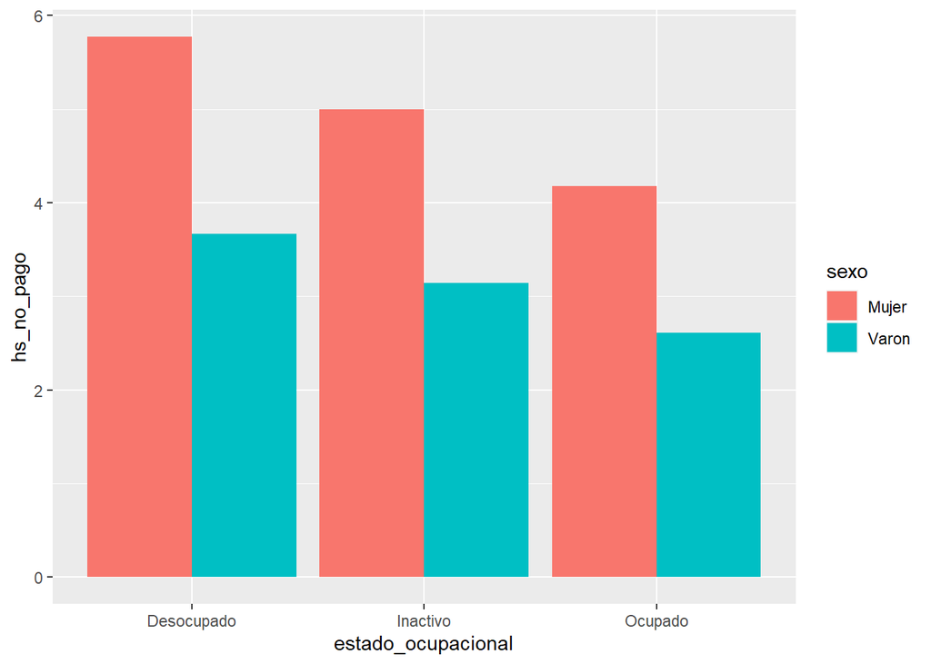

Elaboración propia en base a datos de la Encuesta sobre Uso del Tiempo, Dirección de Estadisticas y Censos, GCBS

```r
horas_no_pago|>
  group_by(sexo, estado_ocupacional)|>
  filter(hs_no_pago>0)|>
  summarise(hs_no_pago = mean(hs_no_pago)) %>%
  ggplot(aes(estado_ocupacional, hs_no_pago)) +
  geom_col(position = "dodge", aes(fill = sexo))
```

```r
  labs(title = paste0("Promedio de horas diarias de trabajo no remunerado según genero y eatado ocupacional "))
```

```
## $title
## [1] "Promedio de horas diarias de trabajo no remunerado según genero y eatado ocupacional "
##
## attr(,"class")
## [1] "labels"
```

### Conclusión hipótesis 2

Los ocupados realizan en promedio menos horas de trabajo no remunerado que los desocupados y que los inactivos.

Cuando este análisis se lo discrimina por género, se observa que las mujeres ocupadas realizan más actividades no remuneradas que los hombres en igual condición laboral,más de 4 horas versus poco menos de 3 respectivamente.Con independencia de la condición laborar, se reafirma la hipótesis 1, que las mujeres realizan más actividades no remuneradas.

## Hipotesis 3: Las personas más jóvenes realizan menos actividades no remuneradas y más recreativas o de estudio.

A continuación se calcula la media de tiempo dedicado a actividades de recreación, estudio/educación o uso de aplicaciones según edad.

```r
horas_no_pago %>%
  group_by(rango_etario) %>%
  summarise(media_no_pago = mean(hs_no_pago, na.rm = TRUE), horas_estudio = mean(estudio_educacion2),horas_recreacion = mean(recreacion2, na.rm = TRUE),horas_aplicaciones = mean(aplicaciones2), horas_pago = mean(trabajo_pago2)) %>%
  knitr::kable(caption = "Promedio de horas de dedicadas a actividades remuneradas y no remuneradas según edad ", col.names = c("Edad agrupada ", "Horas de trabajo no remunerado", "Horas de estudio", "Horas de recreación", "Horas en aplicaciones","Horas de trabajo remunerado"))
```

Promedio de horas de dedicadas a actividades remuneradas y no remuneradas según edad

| Edad agrupada | Horas de trabajo no remunerado | Horas de estudio | Horas de recreación | Horas en aplicaciones | Horas de trabajo remunerado |
| --- | --- | --- | --- | --- | --- |
| 14-24 | 1.515808 | 3.6285223 | 3.523024 | 2.156701 | 2.308247 |
| 25-39 | 3.437054 | 0.6849702 | 2.798661 | 1.307292 | 5.528571 |
| 40-49 | 4.136482 | 0.1664495 | 2.263518 | 1.283388 | 5.910098 |
| 50-64 | 3.536468 | 0.1295585 | 2.285989 | 2.028599 | 5.468906 |
| 65+ | 4.149725 | 0.1009174 | 2.619266 | 3.664220 | 1.343486 |

Los grupos poblacionales más jóvenes (14-24 años) dedican más tiempo a actividades de recreación, aplicaciones y educación. Estos valores caen con los años, hasta llegar a los mayores de 65, quienes comienzan a dedicar más horas diarias a la recreación y al uso de aplicaciones (está última ya en los mayores de 50 comienza a incrementarse).

En el siguiente gráfico, se observa el predominio de horas dedicadas a recreación en las edades jovenes, y como estas horas promedio descienden en las grupos etario.

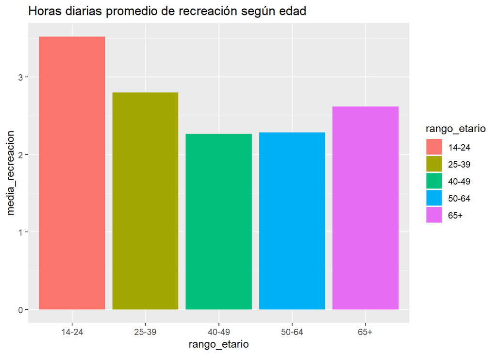

Elaboración propia en base a datos de la Encuesta sobre Uso del Tiempo, Dirección de Estadisticas y Censos, GCBS

```r
uso_tiempo|>
  group_by(rango_etario)|>

    summarise(media_recreacion = mean(recreacion2, na.rm=TRUE))|>

  ggplot(aes(rango_etario, media_recreacion)) +
  geom_col(aes(fill = rango_etario))+

   labs(title = paste0("Horas diarias promedio de recreación según edad "))
```

Se realiza el mismo gráfico para la variable uso de aplicaciones.Aquí se aprecia claramente la diferencia de horas promedio de uso de aplicaciones según la edad de los individuos, con un máximo en los mayores de 65 años (más de 3 horas promedio por día) y valores no muy dispares entre el grupo de 14 a 24 años y los adultos entre 50 y 64 años.

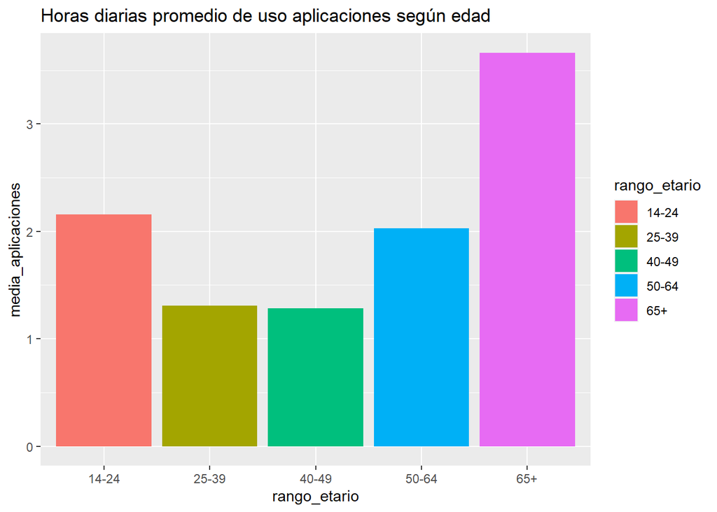

Elaboración propia en base a datos de la Encuesta sobre Uso del Tiempo, Dirección de Estadisticas y Censos, GCBS

```r
uso_tiempo|>
  group_by(rango_etario)|>
summarise(media_aplicaciones = mean(aplicaciones2, na.rm=TRUE))|>
ggplot(aes(rango_etario, media_aplicaciones)) +
  geom_col(aes(fill = rango_etario))+

  labs(title = paste0("Horas diarias promedio de uso aplicaciones según edad "))
```

Mismo análisis para horas de estudio, indicaría un predominio de horas dedicadas estudio logicamente en las edades jovenes (etapa de educacion formal secundario y terciaria) y como estas horas promedio descienden en las grupos etario de manera significativa.

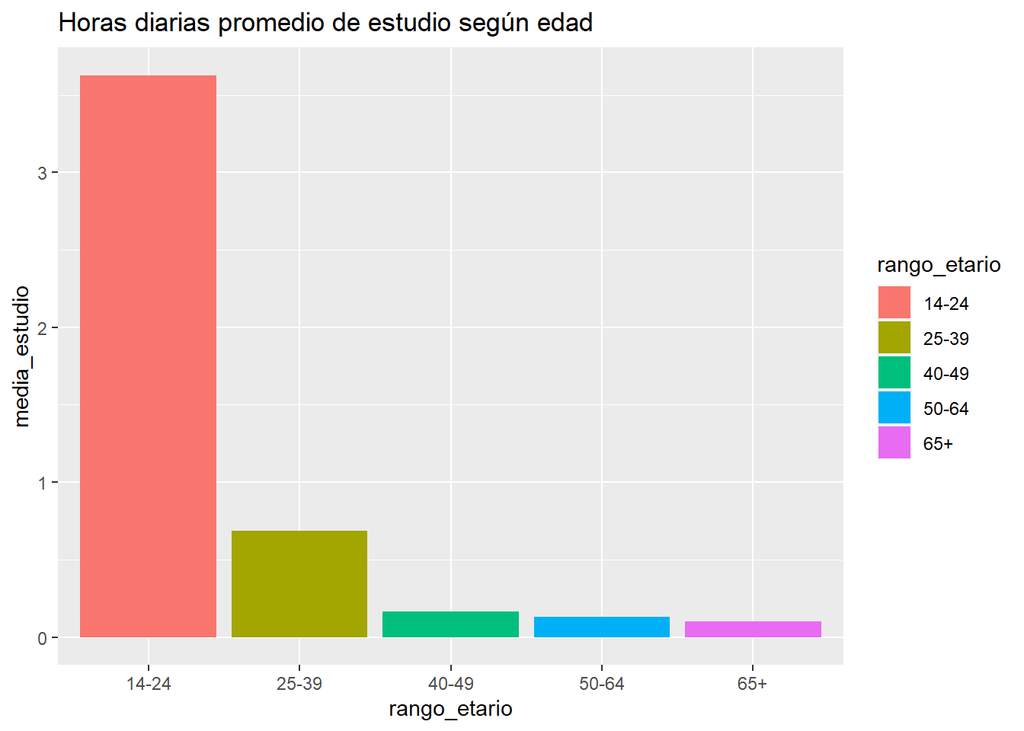

Elaboración propia en base a datos de la Encuesta sobre Uso del Tiempo, Dirección de Estadisticas y Censos, GCBS

```r
uso_tiempo|>
  group_by(rango_etario)|>
summarise(media_estudio = mean(estudio_educacion2, na.rm=TRUE))|>

ggplot(aes(rango_etario, media_estudio)) +
  geom_col(aes(fill =rango_etario))+
  labs(title = paste0("Horas diarias promedio de estudio según edad  "))
```

### Conclusión hipótesis 3.

Los grupos de menor edad destinan más horas promedio a la recreación y al estudio, respecto de los otros grupo etarios. No obstante,en cuento al uso de aplicaciones los adultos de más de 65 superan en la cantidad de horas diarias promedio al grupo de jóvenes.

La mayor brecha se observa logicamente en la cantidad promedio de horas diarias destinadas a estudio. Mientras que los jóvenes de entre 14 y 24 años destinan más de 3 horas promedio diarias, en el resto de los grupos etarios no alcanza a una hora.

## Dificultades

No se encontraron entre las variables disponibles los ponderadores. Por este motivo, el análisis efectuado es solo a modo descriptivo no pudiendo realizarse inferencias ni extrapolaciones a la población total dela Ciudad de Buenos Aires. Tampoco fue posible realizar un análisis teniendo en cuenta el nivel económico de la población,debido a la falta de datos en la variable quintil de ingreso.